# Title of Assignment-2:

```
Implementing Feedforward neural networks with Keras and TensorFlow
a. Import the necessary packages
b. Load the training and testing data (MNIST)
c. Define the network architecture using Keras
d. Train the model using SGD
e. Evaluate the network
f. Plot the training loss and accuracy
```

# Importing libraries

```python
#importing necessary libraries
import tensorflow as tf
from tensorflow import keras
```

```python
import pandas as pd
import numpy as np
import matplotlib.pyplot as plt
import random
%matplotlib inline
```

# Loading and preparing the data

MNIST stands for “Modified National Institute of Standards and Technology”. It is a dataset of 70,000 handwritten images. Each image is of 28x28 pixels i.e. about 784 features. Each feature represents only one pixel’s intensity i.e. from 0(white) to 255(black). This database is further divided into 60,000 training and 10,000 testing images.

```python
#import dataset and split into train and test data
mnist = tf.keras.datasets.mnist  #this accesses the MNIST dataset from TensorFlow's Keras library
## it loads dataset and split into trainig and testing dataset
# xtrain contains training images and y train contains corresponding label
(x_train, y_train), (x_test, y_test) = mnist.load_data()
```

```python
#to see length of training dataset
len(x_train)
```

```
60000
```

```python
##to see length of testing dataset
len(x_test)
```

```
10000
```

```python
#shape of training dataset  60,000 images having 28*28 size
x_train.shape
```

```
(60000, 28, 28)
```

```python
#shape of testing dataset  10,000 images having 28*28 size
x_test.shape
```

```
(10000, 28, 28)
```

```python
# accessing the first image in the training dataset (x_train). This particular image is represented as a 28x28 array of pixel
#values, where each value represents the intensity of that pixel with values ranging from 0 to 255.
x_train[0]
```

[output not shown]

[output cut: 29 more lines]

[output not shown]

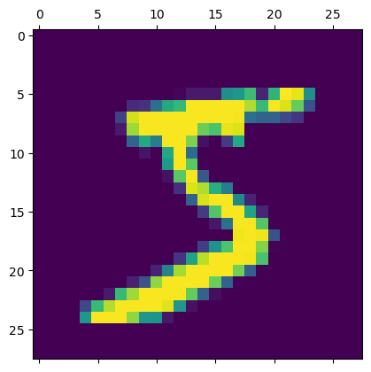

```python
#to see how first image look
plt.matshow(x_train[0])
```

```python
#normalize the images by scaling pixel intensities to the range 0,1
# normalizes the pixel values in x_train and x_test by dividing each pixel by 255, the maximum possible pixel intensity value
# and transferred it in range of 0 to 1

x_train = x_train / 255
x_test = x_test / 255
```

```python
#0 represents no pixel intensity means pixel is black
# other than 0 represent value represent shades of gray.
x_train[0]
```

[output not shown]

[output cut: 113 more lines]

[output not shown]

```python
#Define the network architecture using Keras
```

# Creating the model

The ReLU function is one of the most popular activation functions. It stands for “rectified linear unit”. Mathematically this function is defined as: y = max(0,x)The ReLU function returns “0” if the input is negative and is linear if the input is positive.

The softmax function is another activation function. It changes input values into values that reach from 0 to 1.

```python
# This initializes a neural network model in Keras using the Sequential API it is type of model
# where data flows sequentially, layer by layer, from input to output.
# The Flatten layer reshapes the input data from a 2D array (28x28 pixels, as in a grayscale image)
# into a 1D array of 784 pixels.The Flatten layer reshapes the input data from a 2D array (28x28 pixels,as in a grayscale image)
# into a 1D array of 784 pixels.Dense with 128 neurons:This layer has 128 "neuron Each neuron uses an activation function called
# ReLU,allowing the model to learn more complex patterns.
# Output Layer (Dense with 10 neurons): The final layer has 10 neurons The softmax function here converts the output into
# probabilities. The class with the highest probability is the model’s prediction.


model = keras.Sequential([
    keras.layers.Flatten(input_shape=(28, 28)),
    keras.layers.Dense(128, activation='relu'),
    keras.layers.Dense(10, activation='softmax')
])
```

```python
# detailed overview of the structure of your neural network.
# This means the input is a 28x28 image, and the Flatten layer converts this 2D image into a 1D array of 784 pixels
# The Flatten layer doesn't have any parameters since it simply reshapes the input without changing its data.

# (input units * output units) + output units for biases.
# For this layer, it’s (784 * 128) + 128 = 100,480 parameters.

# This layer has 10 neurons, his is calculated as (128 * 10) + 10 = 1,290 parameters.

model.summary()
```

```
Model: "sequential"
```

```
┏━━━━━━━━━━━━━━━━━━━━━━━━━━━━━━━━━━━━━━┳━━━━━━━━━━━━━━━━━━━━━━━━━━━━━┳━━━━━━━━━━━━━━━━━┓
┃ Layer (type)                         ┃ Output Shape                ┃         Param # ┃
┡━━━━━━━━━━━━━━━━━━━━━━━━━━━━━━━━━━━━━━╇━━━━━━━━━━━━━━━━━━━━━━━━━━━━━╇━━━━━━━━━━━━━━━━━┩
│ flatten (Flatten)                    │ (None, 784)                 │               0 │
├──────────────────────────────────────┼─────────────────────────────┼─────────────────┤
│ dense (Dense)                        │ (None, 128)                 │         100,480 │
├──────────────────────────────────────┼─────────────────────────────┼─────────────────┤
│ dense_1 (Dense)                      │ (None, 10)                  │           1,290 │
└──────────────────────────────────────┴─────────────────────────────┴─────────────────┘
```

```
 Total params: 101,770 (397.54 KB)
```

```
 Trainable params: 101,770 (397.54 KB)
```

```
 Non-trainable params: 0 (0.00 B)
```

# Compile the model

```python
# used to compile the model before training Optimizer is used to adjust the weights of the model during training.
# The Stochastic Gradient Descent (SGD) is the optimizer chosen here ,
# there are 10 possible classes that why i use Sparse Categorical Crossentropy loss function which is used for
# multi-class classification problems,
# Metrics are used to evaluate the model’s performance, Accuracy is chosen here, which measures the percentage of
# correct predictions made by the model


model.compile(optimizer='sgd',
              loss='sparse_categorical_crossentropy',
              metrics=['accuracy'])
```

# Train the model

```python
# #The fit() method is used to train the model. It takes in the training data and other parameters,
# and it performs the training process (i.e., adjusting the model's weights and biases) based on the input data
# (x_test, y_test), which represents the validation set. The purpose of the validation set is to evaluate the model's
# performance on new data
# epochs specifies the number of times the entire training dataset is passed through the model.
# One epoch means one full pass through all the training data.

# output : 1875 steps requires 9s timw means /step 3 milisec acc-%how well model predict correct op and loss how far
#     our model prediction from actual prediction and same for unseen data o.e val-acc


history=model.fit(x_train, y_train,validation_data=(x_test,y_test),epochs=10)
```

```
1875/1875 ━━━━━━━━━━━━━━━━━━━━ 9s 3ms/step - accuracy: 0.7298 - loss: 1.0415 - val_accuracy: 0.9028 - val_loss: 0.3538
1875/1875 ━━━━━━━━━━━━━━━━━━━━ 6s 3ms/step - accuracy: 0.9005 - loss: 0.3563 - val_accuracy: 0.9190 - val_loss: 0.2915
1875/1875 ━━━━━━━━━━━━━━━━━━━━ 6s 3ms/step - accuracy: 0.9155 - loss: 0.3002 - val_accuracy: 0.9261 - val_loss: 0.2615
1875/1875 ━━━━━━━━━━━━━━━━━━━━ 5s 3ms/step - accuracy: 0.9236 - loss: 0.2706 - val_accuracy: 0.9328 - val_loss: 0.2419
1875/1875 ━━━━━━━━━━━━━━━━━━━━ 5s 3ms/step - accuracy: 0.9305 - loss: 0.2419 - val_accuracy: 0.9351 - val_loss: 0.2260
1875/1875 ━━━━━━━━━━━━━━━━━━━━ 6s 3ms/step - accuracy: 0.9367 - loss: 0.2256 - val_accuracy: 0.9406 - val_loss: 0.2080
1875/1875 ━━━━━━━━━━━━━━━━━━━━ 5s 3ms/step - accuracy: 0.9403 - loss: 0.2095 - val_accuracy: 0.9449 - val_loss: 0.1924
1875/1875 ━━━━━━━━━━━━━━━━━━━━ 5s 3ms/step - accuracy: 0.9462 - loss: 0.1928 - val_accuracy: 0.9471 - val_loss: 0.1822
1875/1875 ━━━━━━━━━━━━━━━━━━━━ 5s 3ms/step - accuracy: 0.9517 - loss: 0.1758 - val_accuracy: 0.9510 - val_loss: 0.1724
1875/1875 ━━━━━━━━━━━━━━━━━━━━ 5s 3ms/step - accuracy: 0.9523 - loss: 0.1663 - val_accuracy: 0.9532 - val_loss: 0.1638
```

# Evaluate the model

```python
# used to evaluate the model's performance on the test dataset (which it has never seen before), after training is complete.
# prints the loss and accuracy on the test set, formatted to three decimal places.

test_loss,test_acc=model.evaluate(x_test,y_test)
print("Loss=%.3f" %test_loss)
print("Accuracy=%.3f" %test_acc)
```

```
313/313 ━━━━━━━━━━━━━━━━━━━━ 1s 3ms/step - accuracy: 0.9454 - loss: 0.1889
Loss=0.164
Accuracy=0.953
```

# Making Prediction on New Data

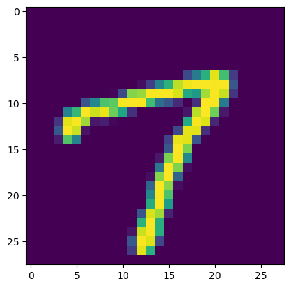

```python
# generates a random index range betn 0 to 9999 to select an image from the test dataset (x_test) and displays it using matplotlib


n=random.randint(0,9999)
plt.imshow(x_test[n])
plt.show()
```

```python
#we use predict() on new data
predicted_value=model.predict(x_test)
print("Handwritten number in the image is= %d" %np.argmax(predicted_value[n]))
```

```
313/313 ━━━━━━━━━━━━━━━━━━━━ 1s 3ms/step
Handwritten number in the image is= 7
```

# Plot graph for Accuracy and Loss

```python
# it is a dictionary containing the training history of the model during the fit() process.
# The dictionary stores key metrics that were tracked during training, such as accuracy, loss,
# validation accuracy, and validation loss for each epoch

history.history??
```

[output not shown]

```python
history.history.keys()
```

```
dict_keys(['accuracy', 'loss', 'val_accuracy', 'val_loss'])
```

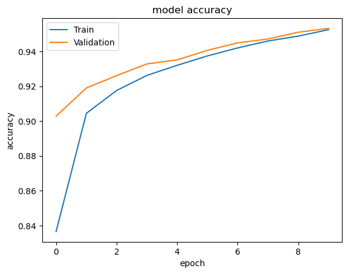

```python
plt.plot(history.history['accuracy'])
plt.plot(history.history['val_accuracy'])
plt.title('model accuracy')
plt.ylabel('accuracy')
plt.xlabel('epoch')
plt.legend(['Train', 'Validation'], loc='upper left')
plt.show()
```

graph representing the model’s accuracy

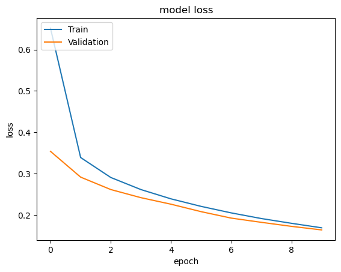

```python
plt.plot(history.history['loss'])
plt.plot(history.history['val_loss'])
plt.title('model loss')
plt.ylabel('loss')
plt.xlabel('epoch')
plt.legend(['Train', 'Validation'], loc='upper left')
plt.show()
```

graph represents the model’s loss

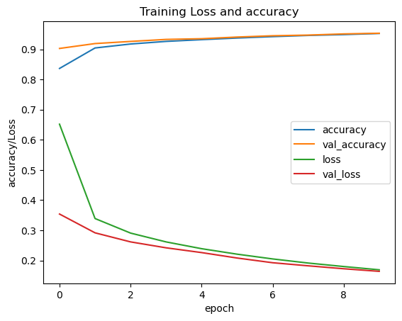

```python
plt.plot(history.history['accuracy'])
plt.plot(history.history['val_accuracy'])
plt.plot(history.history['loss'])
plt.plot(history.history['val_loss'])
plt.title('Training Loss and accuracy')
plt.ylabel('accuracy/Loss')
plt.xlabel('epoch')
plt.legend(['accuracy', 'val_accuracy','loss','val_loss'])
plt.show()
```

Conclusion: With above code We can see, that throughout the epochs, our model accuracy increases and our model loss decreases,that is good since our model gains confidence with its predictions.

```
1. The two losses (loss and val_loss) are decreasing and the accuracy
   (accuracy and val_accuracy)are increasing.
    So this indicates the model is trained in a good way.

2. The val_accuracy is the measure of how good the predictions of your model are.
   So In this case, it looks like the model is well trained after 10 epochs
```

```python
#pwd
```